# Prosper Loan Exploration

## by James Franchino

## Investigation Overview

In this investigation I wanted to investigate two main things:

- What metrics can be used to predict credit defaults?
- Does the loan term have an effect on default?

## Dataset Overview

This data set contains 113937 rows, with 81 columns containing information about loans made through Prosper, a peer-to-peer lending platform. For the purpose of this analysis, I'm using the following columns: 'Term', 'LoanStatus', 'BorrowerRate', 'ProsperRating (Alpha)', 'ListingCategory (numeric)', 'EmploymentStatus', 'DelinquenciesLast7Years', 'StatedMonthlyIncome', 'TotalProsperLoans', 'LoanOriginalAmount', 'LoanOriginationDate', 'Recommendations', 'Investors'.

## Loan status

First we need to look at the status of the loans in our dataset. What this graph tells us is:

- Most of the loans are current, not late or in default, and not completed (paid off).
- Completed loans are our second biggest category.
- Past due loans are split into several categories based on the amount of days past due.

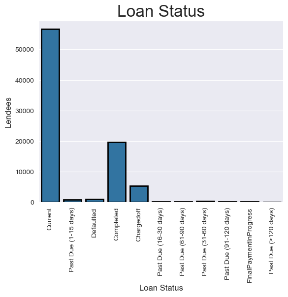

## Stated Monthly Income

Next we will look at the stated monthly income of all lendees. From this graph what we've learned is:

- We can see that the majority of lendees land around $5000 in monthly income.

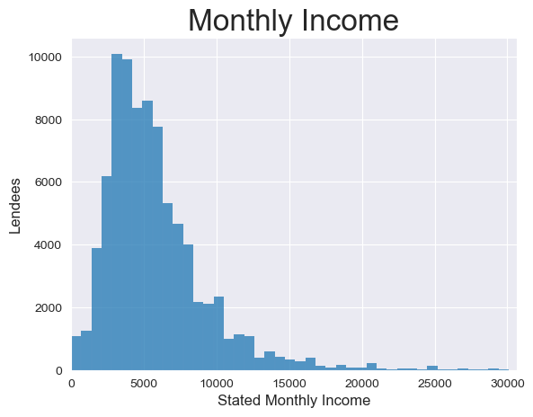

## Term Lengths

Let's take a look at term lengths next. As we can see in the below graph, 36 month (3 year) loans are by far the most popular loans given through Prosper.

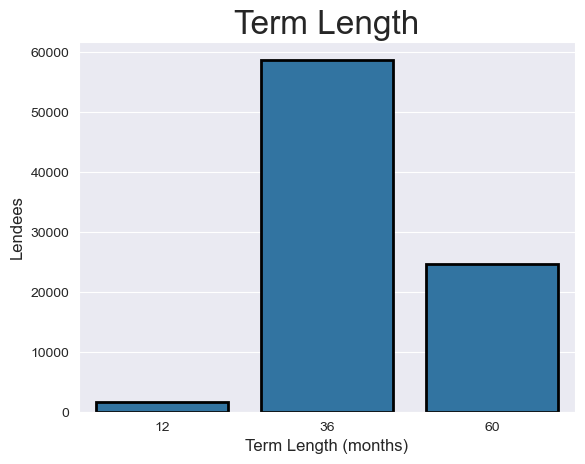